# GC biases

```r
library("devtools")
load_all("M:/GOcategoryStats")
```

```
Loading GOcategoryStats
```

github

biases/processing/in_silico/filter_gene_info.pl

# Filters a gene info file (created using the script create_gene_info_from_file.pl which is located here:

# https://github.com/s-andrews/GOliath/blob/master/processing/gene_info_processing/create_gene_info_file_from_gtf.pl)

Generate lists of mouse genes by GC content.

Downloaded the raw version of the file from github `wget https://raw.githubusercontent.com/s-andrews/GOliath/master/processing/gene_info_processing/create_gene_info_file_from_gtf.pl`

Run this script to get gene info `perl create_gene_info_file_from_gtf.pl --gtf Mus_musculus.GRCm38.94.gtf.gz --genome GRCm38`

We’ll import the gene info file so that we can plot the GC distribution for all genes in the Mus_musculus.GRCm38.94.gtf.gz genome. There are import_GTF and parse_GTF_info functions within the GOcategoryStats package but to get genome information i.e. GC content, the parsing and lookups need to be done with access to genome information, so on the cluster. The import_GTF and parse_GTF_info functions just work with the gtf file itself.

Plot out the GC distribution for all the genes in Mus_musculus.GRCm38.94

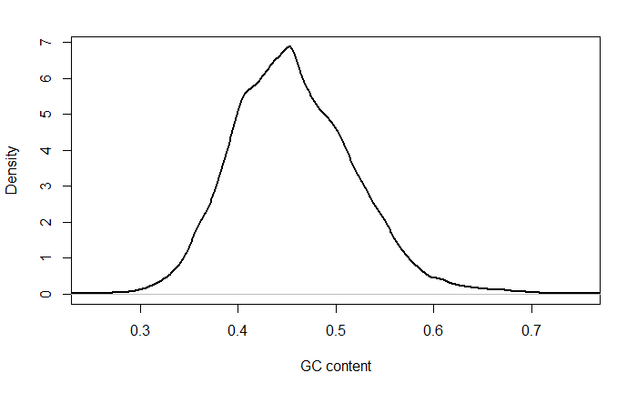

```r
genfo <- read.delim("D:/projects/biases/GC_content_biased/Mus_musculus.GRCm38.94_gene_info.txt")
plot(density(genfo$GC_content), lwd = 2, main = "", xlab = "GC content", xlim = c(0.25,0.75))
```

Filter the gene info/genfo file for high and low GC contents

`wget https://raw.githubusercontent.com/laurabiggins/biases/master/processing/in_silico/filter_gene_info.pl`

```r
sum(genfo$GC_content < 0.4)
```

Filtering of the file takes place first, then the specified number of genes are randomly selected.

`for i in {1..100}; do ./filter_gene_info.pl --max_GC 0.39999 Mus_musculus.GRCm38.94_gene_info.txt --number_of_genes 200 --output_file lowGC_${i}; done`

Extract the gene names and remove header `for i in lowGC*; do cut -f2 $i | tail -n 200 > ${i}_just_genes.txt; done`

```r
files <- list.files(path = "M:/biased_gene_lists/GC_content_biased/lowGC", pattern = "just_genes.txt", full.names = TRUE)
lowGC <- lapply(files, function(x) scan(x, what = "character"))
```

Run the gene lists through a GO overrepresentation analysis.

```r
go_results <- overrep_test(all_go_categories, lowGC[[1]], bg_genes)
head(go_results)

all_go_results <- lapply(lowGC, function(query){
  overrep_test(all_go_categories, query, bg_genes)
  })

#save(all_go_results, file = "D:/projects/biases/GC_content_biased/lowGC/lowGC_results.rda")
save(all_go_results, file = "M:/GOcategoryStats/data/lowGC_results.rda")
# this only took a minute or 2 but still worth saving
```

```r
#load("D:/projects/biases/GC_content_biased/lowGC/lowGC_results.rda")
load("M:/GOcategoryStats/data/lowGC_results.rda")
all_sig_categories <- unlist(sapply(all_go_results, rownames))
tabled_categories  <- table(all_sig_categories)
ordered_categories <- tabled_categories[order(tabled_categories, decreasing = TRUE)]
#filename <- paste0("GO_summary_", length(top200), "_datasets.txt" )
#write.table(x = ordered_categories, filename, quote = FALSE, row.names = FALSE, sep = "\t")
```

Now we could do with some stats to pick a cutoff for the number of times a category appears. Let’s just select an arbitrary value of 15 for now….

## Create a dataset that contains these suspect set of categories

```r
suspects_lowGC <- ordered_categories[ordered_categories >= 15]

# convert to proportions
suspects_lowGC <- signif(suspects_lowGC/length(suspects_lowGC), digits = 2)

suspects_lowGC <- names(suspects_lowGC)

head(suspects_lowGC)
```

```r
save(suspects_lowGC, file = "M:/GOcategoryStats/data/suspects_lowGC.rda")

writeClipboard(suspects_lowGC)
```

## High GC

Didn’t get any significant categories using GC > 0.55 or 0.6, though I did before - it may be that the filters such as the max number of genes is too strict?

`for i in {1..100}; do ../filter_gene_info.pl --max_GC 0.6 ../Mus_musculus.GRCm38.94_gene_info.txt --number_of_genes 200 --output_file highGC_0.6_${i}; done`

Extract the gene names and remove header `for i in highGC*; do cut -f2 $i | tail -n 200 > ${i}_just_genes.txt; done`

```r
#file <- "http://download.baderlab.org/EM_Genesets/current_release/Mouse/symbol/Mouse_GO_AllPathways_no_GO_iea_December_01_2018_symbol.gmt"
#' x <- processGMTFile(file, 5, 5000)
#more_go_categories <- process_GMT(file, 3, 10000)
```

```r
sum(genfo$GC_content >= 0.6)
files <- list.files(path = "D:/projects/biases/GC_content_biased/highGC", pattern = ".txt", full.names = TRUE)
highGC <- lapply(files, function(x) scan(x, what = "character"))
```

```r
go_results1 <- overrep_test(all_go_categories, highGC[[1]], bg_genes, mult_test = FALSE, pval_threshold = 0.2)
go_results <- overrep_test(more_go_categories, highGC[[1]], bg_genes, pval_threshold = 1)
head(go_results)

all_go_results <- lapply(highGC, function(query){
  overrep_test(all_go_categories, query, bg_genes, mult_test = FALSE)
  })

all_sig_categories <- unlist(sapply(all_go_results, rownames))
tabled_categories <- table(all_sig_categories)
ordered_categories <- tabled_categories[order(tabled_categories, decreasing = TRUE)]
head(ordered_categories)
```